# topcompanies

```python
import pandas as pd
import numpy as np
import matplotlib.pyplot as plt
import seaborn as sns
import plotly.express as px
sns.set_theme(color_codes=True)
pd.set_option('display.max_columns', None)
```

## Limpieza de datos

```python
df = pd.read_excel('Top_1000_companies_DataSet.xlsx')
```

```python
df.drop_duplicates() #no hay dupliciados

df.dtypes # los formatos/tipos de datos
```

```
company_name           object
url                    object
city                   object
state                  object
country                object
employees              object
linkedin_url           object
founded                object
Industry               object
GrowjoRanking          object
Previous Ranking       object
estimated_revenues     object
job_openings           object
keywords               object
LeadInvestors          object
Accelerator            object
btype                  object
valuation             float64
total_funding          object
product_url            object
indeed_url             object
growth_percentage     float64
contact_info           object
dtype: object
```

Eliminar duplicados

```python
df.drop_duplicates()
```

|  | company_name | url | city | state | country | employees | linkedin_url | founded | Industry | GrowjoRanking | Previous Ranking | estimated_revenues | job_openings | keywords | LeadInvestors | Accelerator | btype | valuation | total_funding | product_url | indeed_url | growth_percentage | contact_info |
| --- | --- | --- | --- | --- | --- | --- | --- | --- | --- | --- | --- | --- | --- | --- | --- | --- | --- | --- | --- | --- | --- | --- | --- |
| 0 | OpenAI | openai.com | San Francisco | CA | United States | 655 | http://www.linkedin.com/company/openai | 2015 | AI | 1 | 1 | 88722200 | 25 | Artificial Intelligence, Online Gaming, Non Pr... | Thrive, Founders Fund | NaN | NaN | 2.900000e+10 | $11B | https://www.growjo.com/company/OpenAI | https://www.indeed.com/jobs?q=company%3A(OpenAI) | 1.18 | For Contact Direct Phone Numbers and Emails se... |
| 1 | Alchemy | alchemy.com | San Francisco | CA | United States | 201 | http://www.linkedin.com/company/alchemyinc | NaN | Fintech | 2 | 2 | 39269750 | 1 | NaN | Lightspeed, Silver Lake | NaN | NaN | 1.020000e+10 | $564M | https://www.growjo.com/company/Alchemy | https://www.indeed.com/jobs?q=company%3A(Alchemy) | 1.34 | For Contact Direct Phone Numbers and Emails se... |
| 2 | dbt Labs | getdbt.com | Philadelphia | PA | United States | 511 | http://www.linkedin.com/company/dbtlabs | 2016 | Analytics | 3 | 3 | 76987400 | 1 | NaN | Altimeter | NaN | NaN | 4.200000e+09 | $414.4M | https://www.growjo.com/company/dbt_Labs | https://www.indeed.com/jobs?q=company%3A(dbt L... | 0.76 | For Contact Direct Phone Numbers and Emails se... |
| 3 | Wasabi Technologies | wasabi.com | Boston | MA | United States | 355 | http://www.linkedin.com/company/wasabitechnolo... | 2017 | Cloud | 4 | 4 | 38480000 | 4 | saas | L2 Point | NaN | NaN | 1.100000e+09 | $286.2M | https://www.growjo.com/company/Wasabi_Technolo... | https://www.indeed.com/jobs?q=company%3A(Wasab... | 0.60 | For Contact Direct Phone Numbers and Emails se... |
| 4 | Whatnot | whatnot.com | Los Angeles | CA | United States | 551 | http://www.linkedin.com/company/whatnot-inc | 2019 | eCommerce | 5 | 5 | 39664000 | 1 | NaN | DST Global | NaN | NaN | 3.700000e+09 | $484.7M | https://www.growjo.com/company/Whatnot | https://www.indeed.com/jobs?q=company%3A(Whatnot) | 0.97 | For Contact Direct Phone Numbers and Emails se... |
| ... | ... | ... | ... | ... | ... | ... | ... | ... | ... | ... | ... | ... | ... | ... | ... | ... | ... | ... | ... | ... | ... | ... | ... |
| 976 | Forte | forte.io | San Francisco | CA | United States | 145 | http://www.linkedin.com/company/forte-labs-inc | 2018 | Fintech | 992 | 999 | 28369250 | 1 | NaN | NaN | NaN | NaN | 1.000000e+09 | $910M | https://www.growjo.com/company/Forte | https://www.indeed.com/jobs?q=company%3A(Forte) | 0.04 | For Contact Direct Phone Numbers and Emails se... |
| 977 | Collective Health | collectivehealth.com | San Francisco | CA | United States | 615 | http://www.linkedin.com/company/collectivehealth | 2013 | Digital Health | 993 | 1000 | 114858800 | 40 | digital health, healthtech, saas | NaN | NaN | NaN | NaN | NaN | NaN | NaN | NaN | NaN |
| 978 | NaN | Google Ventures | NaN | NaN | 1500000000 | $719M | https://www.growjo.com/company/Collective_Health | https://www.indeed.com/jobs?q=company%3A(Colle... | 0.04 | For Contact Direct Phone Numbers and Emails se... | NaN | NaN | NaN | NaN | NaN | NaN | NaN | NaN | NaN | NaN | NaN | NaN | NaN |
| 979 | Fathom (YC W21) | fathom.video | San Francisco | CA | USA | 96 | http://www.linkedin.com/company/fathom-video | 2020 | Tech Services | 999 | 1006 | 14645000 | 1 | NaN | NaN | NaN | NaN | NaN | NaN | https://www.growjo.com/company/Fathom_(YC_W21) | https://www.indeed.com/jobs?q=company%3A(Fatho... | 2.31 | For Contact Direct Phone Numbers and Emails se... |
| 980 | Hone | honehq.com | San Francisco | CA | United States | 179 | http://www.linkedin.com/company/honehq | 2018 | EdTech | 1000 | 1007 | 28294000 | 1 | saas | NaN | NaN | NaN | NaN | $22.4M | https://www.growjo.com/company/Hone | https://www.indeed.com/jobs?q=company%3A(Hone) | 0.60 | For Contact Direct Phone Numbers and Emails se... |

981 rows × 23 columns

Deshacerse ede las fials que contengan datos nan y reamplzar en blanco

```python
df = df.fillna('')
```

Eliminar las filas que no contengan datos de la tabla principal

```python
for x in df.index:
    if df.loc[x, "company_name"] == '':
        df.drop(x, inplace=True)
```

Eliminar todos los datos diferentes que no esten en el abecedario o en los numeros del 1 al 9

```python
df["company_name"] = df["company_name"].str.replace('[^a-zA-Z0-9]',' ')
df["city"] = df["city"].str.replace('[^a-zA-Z0-9]',' ')
```

Revisar la informacion de los datos

```python
df.info()
```

```
<class 'pandas.core.frame.DataFrame'>
Int64Index: 965 entries, 0 to 980
Data columns (total 23 columns):
 #   Column              Non-Null Count  Dtype
---  ------              --------------  -----
 0   company_name        965 non-null    object
 1   url                 965 non-null    object
 2   city                965 non-null    object
 3   state               965 non-null    object
 4   country             965 non-null    object
 5   employees           965 non-null    object
 6   linkedin_url        965 non-null    object
 7   founded             965 non-null    object
 8   Industry            965 non-null    object
 9   GrowjoRanking       965 non-null    object
 10  Previous Ranking    965 non-null    object
 11  estimated_revenues  965 non-null    object
 12  job_openings        965 non-null    object
 13  keywords            965 non-null    object
 14  LeadInvestors       965 non-null    object
 15  Accelerator         965 non-null    object
 16  btype               965 non-null    object
 17  valuation           965 non-null    object
 18  total_funding       965 non-null    object
 19  product_url         965 non-null    object
 20  indeed_url          965 non-null    object
 21  growth_percentage   965 non-null    object
 22  contact_info        965 non-null    object
dtypes: object(23)
memory usage: 213.2+ KB
```

Eliminar las columnas que no necesitamos

```python
columnas_a_eliminar = ["contact_info","product_url","indeed_url","Accelerator","btype","keywords","linkedin_url","url","Previous Ranking"]
df = df.drop(columns = columnas_a_eliminar)
df = df.drop(680)
df = df.drop(688)
df = df.drop(738)
df = df.drop(740)
```

Resetear los index porque se acabana de eliminar el index 680

```python
df = df.reset_index(drop=True)
```

convertir el formato de algunas columnas

```python
df["employees"] = df["employees"].apply(lambda x: str(x))
df["founded"] = df["founded"].apply(lambda x: str(x))
df["estimated_revenues"] = df["estimated_revenues"].apply(lambda x: str(x))
df["job_openings"] = df["job_openings"].apply(lambda x: str(x))
df["growth_percentage"] = df["growth_percentage"].apply(lambda x: str(x))
```

Reemplazar valores desconocidos por los valores 0 para int y desconocido para str

```python
df["founded"] = df["founded"].replace('','0')
df["state"] = df["state"].replace('','desconocido')
df["city"] = df["city"].replace('','desconocido')
df["country"] = df["country"].replace('','desconocido')
df["Industry"] = df["Industry"].replace('','desconocido')
df["estimated_revenues"] = df["estimated_revenues"].replace('','0')
df["job_openings"] = df["job_openings"].replace('','0')
df["LeadInvestors"] = df["LeadInvestors"].replace('','desconocido')
df["valuation"] = df["valuation"].replace('','0')
df["total_funding"] = df["total_funding"].replace('','0')
df["growth_percentage"] = df["growth_percentage"].replace('','0')
```

Convertir las columnas de numeros a enteros

```python
df["employees"] = df["employees"].apply(lambda x: int(x))
df["GrowjoRanking"] = df["GrowjoRanking"].apply(lambda x: int(x))
df["founded"] = df["founded"].apply(lambda x: int(x))
df["valuation"] = df["valuation"].apply(lambda x: int(x))
df["estimated_revenues"] = df["estimated_revenues"].apply(lambda x: float(x))
df["growth_percentage"] = df["growth_percentage"].apply(lambda x: float(x))
df["job_openings"] = df["job_openings"].apply(lambda x: int(x))
```

Eliminar los caracteres extraños en la columna de tota_funding

```python
df['total_funding'] = df['total_funding'].str.replace(r'[^0-9MmBb.]', '', regex=True)
```

Necesitamos convertir la columna total_funding en una columna que solo contenga numeros

```python
df['total_funding'] = df['total_funding'].replace({'M': 'e6', 'B': 'e9'}, regex=True)
df['total_funding'] = pd.to_numeric(df['total_funding'], errors='coerce')
df["total_funding"] = df["total_funding"].apply(lambda x: int(x))
```

Este codigo es preferencial para convertir los datos limpios en xlsx

```python
output_file = "top_companies_cleaning.xlsx"
df.to_excel(output_file, index=False)
```

```python
df.select_dtypes(include='object').nunique()
```

```
company_name     942
city             327
state             54
country           61
Industry         120
LeadInvestors    356
dtype: int64
```

Neceitamos convertir los paises a regiones y para eso debemos reemplazar los nomnbres de algunos paises

```python
df["country"] = df["country"].replace('AUS','Australia')
df["country"] = df["country"].replace('Aus','Australia')
df["country"] = df["country"].replace('CAN','Canada')
df["country"] = df["country"].replace('GEN','Germany')
df["country"] = df["country"].replace('Ger','Germany')
df["country"] = df["country"].replace('IE','Irelanda')
df["country"] = df["country"].replace('Ind','India')
df["country"] = df["country"].replace('Netharlands','Netherlands')
df["country"] = df["country"].replace('NO','Norway')
df["country"] = df["country"].replace('NOR','Norway')
df["country"] = df["country"].replace('POL','Polonia')
df["country"] = df["country"].replace('SGP','Singapore')
df["country"] = df["country"].replace('SWE','Sweden')
df["country"] = df["country"].replace('USA','United States')
df["country"] = df["country"].replace('United State','United States')
```

Convertir los paises en regiones

```python
def segment_country(country):
    if country in ["China", "Hong Kong", "India", "Indonesia", "Israel", "Japan", "Kuwait", "Pakistan", "Singapore", "South Korea", "Taiwan", "Thailand", "Turkey", "United Arab Emirates"]:
        return 'Asia'
    elif country in ["Austria", "Belgium", "Cyprus", "Estonia", "Finland", "France", "Germany", "Ireland", "Irelanda", "Italy", "Liechtenstein", "Lithuania", "Netherlands", "Norway", "Poland", "Romania", "Spain", "Sweden", "Switzerland", "UK"]:
        return 'Europe'
    elif country in ["Canada", "Mexico", "Panama", "United States"]:
        return 'North America'
    elif country in ["Brazil", "Colombia", "Ecuador"]:
        return 'South America'
    elif country in ["Egypt", "Kenya", "Namibia", "Seychelles", "South Africa"]:
        return 'Africa'
    elif country in ["Australia", "New Zealand"]:
        return 'Oceania'
    else:
        return 'Others'
```

Aplicar la función de segmentación para crear la nueva columna

```python
df['region'] = df['country'].apply(segment_country)
```

```python
# Agregar una columna de años para hacer graficos de barras por fechas
df['año'] = range(1800, 1800 + len(df))
```

Graficar Regiones

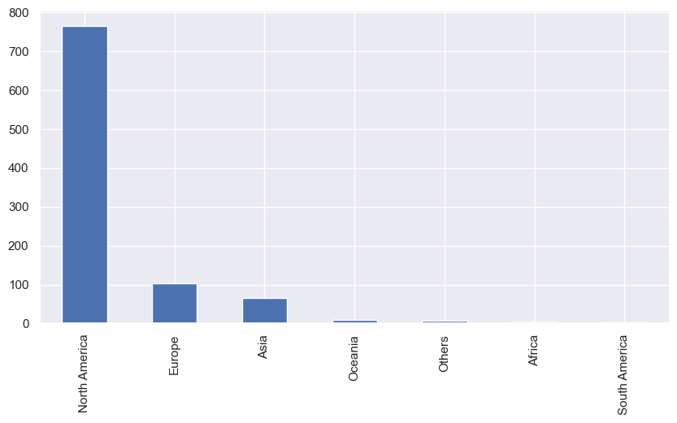

```python
plt.figure(figsize=(10,5))
df['region'].value_counts().plot(kind='bar')
```

### EDA EXPLORATORY DATA ANALYSIS

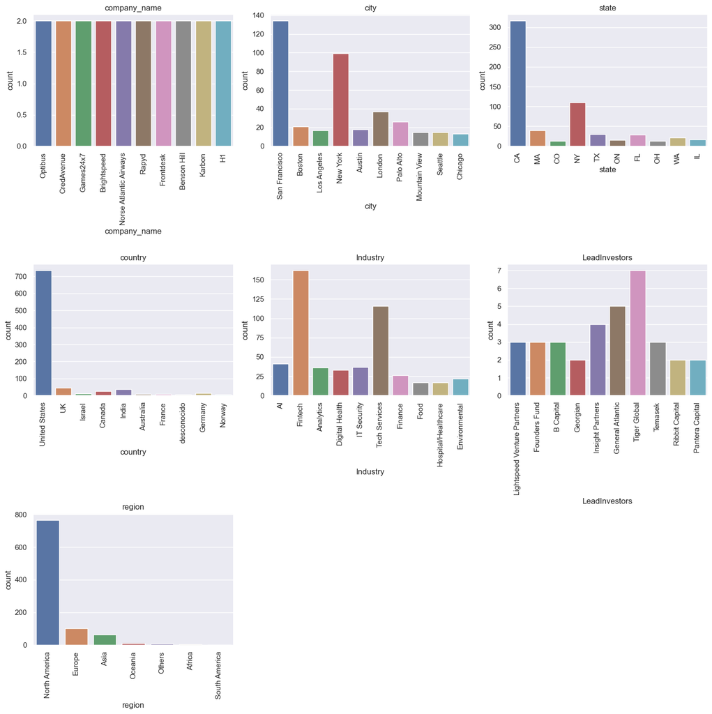

```python
#Obtener los nombres de todas las columnas con el tipo de dato objetos (catagorical num)
cat_vars = df.select_dtypes(include='object').columns.tolist()

# Crear los espacios para las gráficas
num_cols = len(cat_vars)
num_rows = (num_cols + 2) // 3
fig, axs = plt.subplots(nrows=num_rows, ncols=3, figsize=(15, 5*num_rows))
axs = axs.flatten()

# Crear un contador de gráficas para los 5 primeros valores de cada variable categórica usando seaborn
for i, var in enumerate(cat_vars):
    # Excluir 'desconocido' de las columnas leadinvestors y state
    if var in ['LeadInvestors', 'state']:
        top_values = df[df[var] != 'desconocido'][var].value_counts().nlargest(10).index
        filtered_df = df[df[var].isin(top_values)]
    else:
        top_values = df[var].value_counts().nlargest(10).index
        filtered_df = df[df[var].isin(top_values)]

    sns.countplot(x=var, data=filtered_df, ax=axs[i])
    axs[i].set_title(var)
    axs[i].tick_params(axis='x', rotation=90)

# Eliminar cada espacio extra en los gráficos
if num_cols < len(axs):
    for i in range(num_cols, len(axs)):
        fig.delaxes(axs[i])

# Ajustar los espacios entre las gráficas
fig.tight_layout()

plt.show()
#conteo_valores = df['LeadInvestors'].value_counts()
```

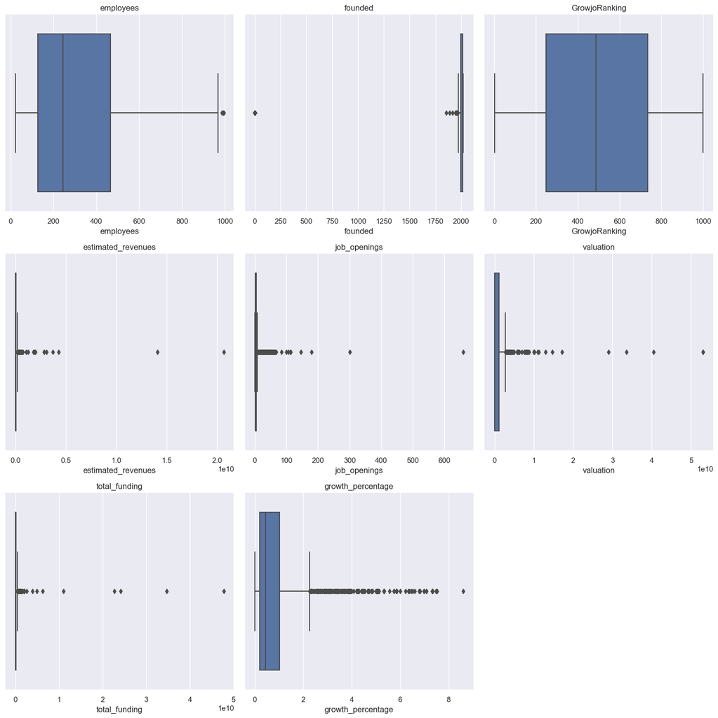

```python
#Escoger los nombres de las columnas con los datos tipo 'int' o 'float'
num_vars = df.select_dtypes(include=['int', 'float']).columns.tolist()

#Crear un espacio para cada grafica
num_cols = len(num_vars)
num_rows = (num_cols + 2) //3
fig, axs = plt.subplots(nrows=num_rows, ncols=3, figsize=(15, 5*num_rows))
axs = axs.flatten()

#Crear un boxplot para cada variable númerica usando Seaborn
for i, var in enumerate(num_vars):
    sns.boxplot(x=df[var], ax=axs[i])
    axs[i].set_title(var)

#Eliminar los expacios extras que no se graficaron
if num_cols < len(axs):
    for i in range(num_cols, len(axs)):
        fig.delaxes(axs[i])

#Ajustar los espacios entre las graficas
fig.tight_layout()
plt.show()
```

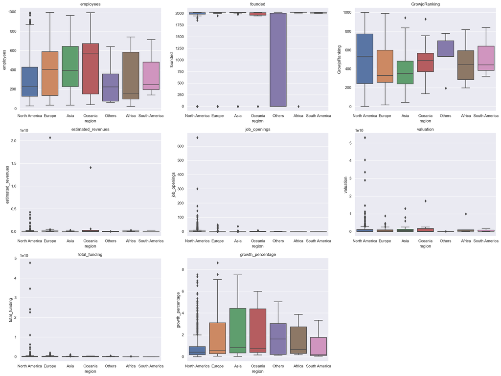

```python
# Escogemos los nombre de todas las columnas con los datos 'int' "Numeros enteros"
int_vars = df.select_dtypes(include=['int', 'float']).columns.tolist()

#Crear las figuras/espacios para los graficos
num_cols = len(int_vars)
num_rows = (num_cols + 2)// 3 # Asegurate que son los espacios suficientes para todas las graficas
fig, axs = plt.subplots(nrows=num_rows, ncols=3, figsize=(20, 5*num_rows))
axs = axs.flatten()

#crear un box-plot para cada varibles usando seaborn con hue='attritio'

for i, var in enumerate(int_vars):
    sns.boxplot(y=var, x='region', data=df , ax=axs[i])
    axs[i].set_title(var)

# Eliminar cada espacio extra que o hayan llenado los graficos
if num_cols < len(axs):
    for i in range(num_cols, len(axs)):
       fig.delaxes(axs[i])

# Ajustar los espacios de os graficos y los titulos
fig.tight_layout()

plt.show()
```

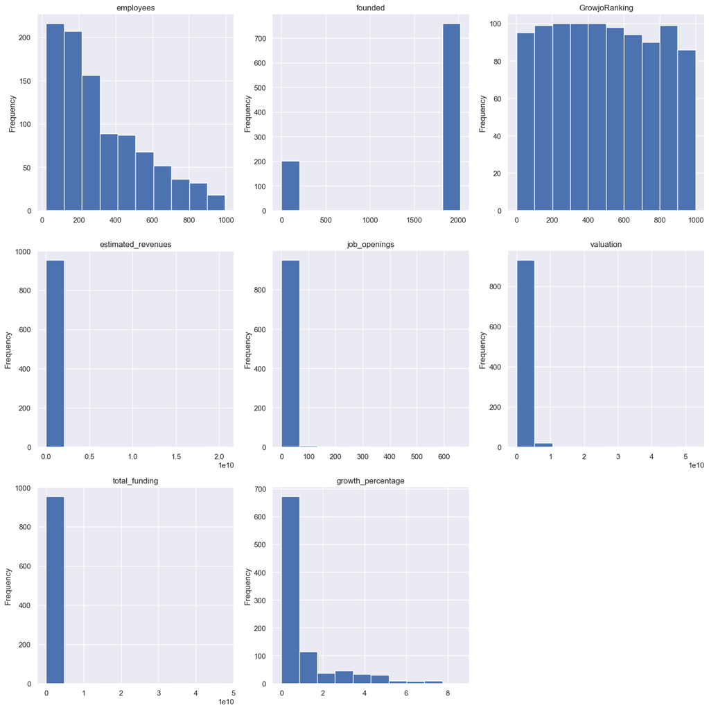

```python
#Escoger los nombres de todas las columnas que contengan datos 'int' y 'float'
int_vars = df.select_dtypes(include=['int','float']).columns.tolist()

#Crear los esopacios para las graficas
num_cols = len (int_vars)
num_rows = (num_cols + 2) //3
fig, axs = plt.subplots(nrows=num_rows, ncols=3, figsize=(15, 5*num_rows))
axs = axs.flatten()

# Crear un histograma por cada variable entero}
for i, var in enumerate(int_vars):
    df[var].plot.hist(ax=axs[i])
    axs[i].set_title(var)

# Elimnar los espacios extras y dejar solo los que necesitamos
if num_cols < len(axs):
    for i in range(num_cols, len(axs)):
        fig.delaxes(axs[i])

# Ajustar los espacios entre las graficas
fig.tight_layout()

plt.show()
```

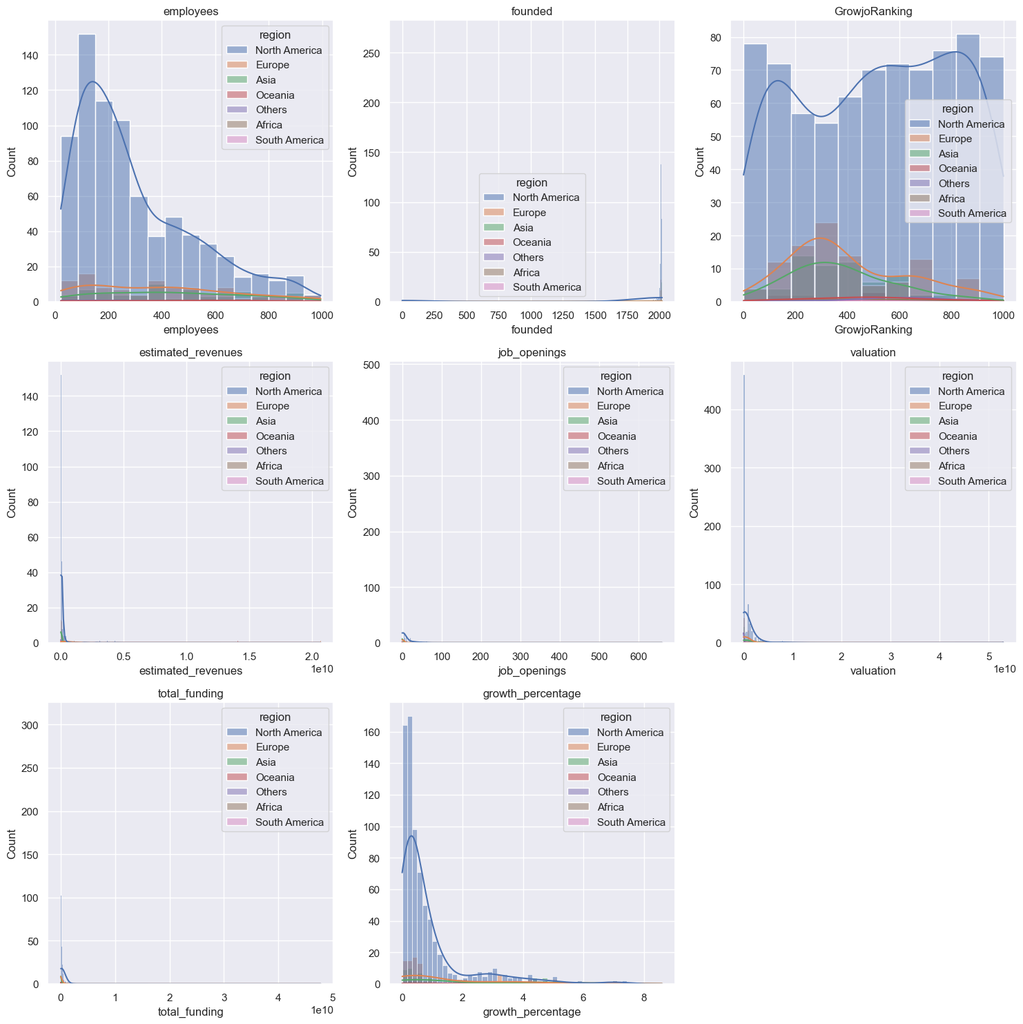

```python
#Obtener los nombres de toidas las comlumnas de tipo 'int' (Entero)

int_vars = df.select_dtypes(include=['int', 'float']).columns.tolist()

#Crear una fuigura con los espacios de las graficas
num_cols = len(int_vars)
num_rows = (num_cols + 2) // 3 # To make sure there are enough rows for the subplots
fig, axs = plt.subplots(nrows=num_rows, ncols=3, figsize=(15, 5*num_rows))
axs = axs.flatten()

#Crear un histograma para cada variable con hue='Attrition'
for i, var in enumerate(int_vars):
    sns.histplot(data=df, x=var, hue='region', kde=True, ax=axs[i])
    axs[i].set_title(var)

# Eliminar los espacios de graficos que no se necesitan
if num_cols < len(axs):
    for i in range(num_cols, len(axs)):
        fig.delaxes(axs[i])

# Ajustar los espacios entre las graficas
fig.tight_layout()

plt.show()
```

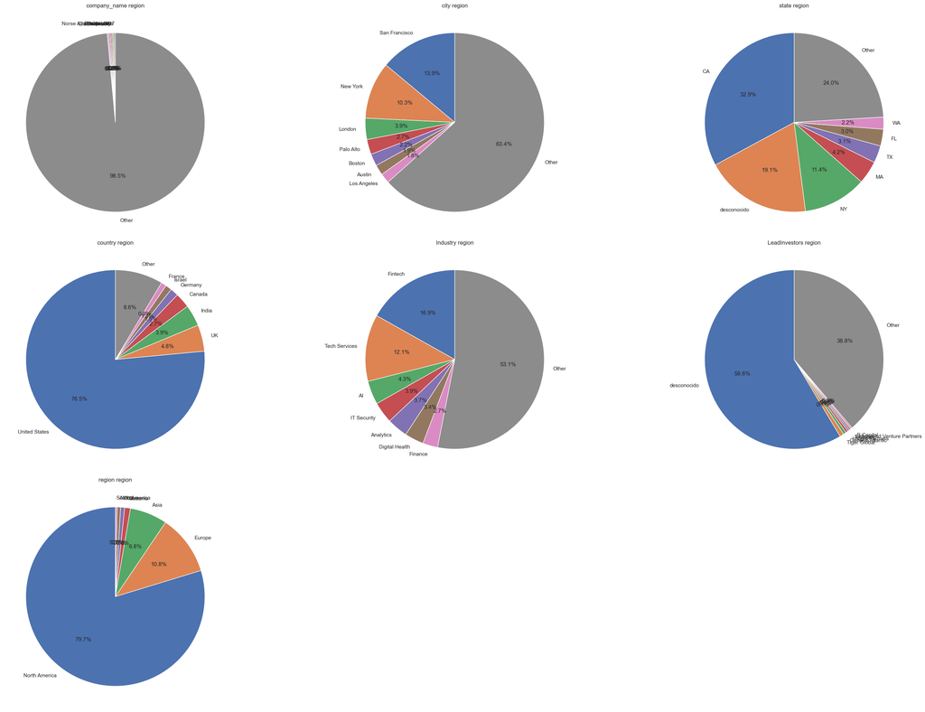

```python
#Especificar el número maximo de de categorías a mostrar individualmente
max_categories = 7

# Filtrar las columnas categoricas con tip 'objeto'
cat_cols = [col for col in df.columns if df[col].dtype == 'object']

# Crear los espacios de los graficos
num_cols = len(cat_cols)
num_rows = (num_cols + 2) // 3
fig, axs = plt.subplots(nrows=num_rows, ncols=3, figsize=(30, 7*num_rows))

# Aplana la matriz axs para facilitar la indexación
axs = axs.flatten()

# Crear la torta para cada columna categorica
for i, col in enumerate(cat_cols):
    if i < len(axs): # Ensure we don't exceed the number of subplots
        #Count the number of occurrences for each category
        cat_counts = df[col].value_counts()

        # Categorías de grupo más allá de max_categories superiores como 'Otros'
        if len(cat_counts) > max_categories:
            cat_counts_top = cat_counts[:max_categories]
            cat_counts_other = pd.Series(cat_counts[max_categories:].sum(), index=["Other"])
            cat_counts = cat_counts_top.append(cat_counts_other)


        # Crear una torta
        axs[i].pie(cat_counts, labels=cat_counts.index, autopct='%1.1f%%', startangle=90)
        axs[i].set_title(f'{col} region')

 #eliminar cada espacio extra
if num_cols < len(axs):
    for i in range(num_cols, len(axs)):
        fig.delaxes(axs[i])

# Ajusta el espacio entre las graficas
fig.tight_layout()

plt.show()
```

```python
df[{'founded','Industry','company_name'}]
graph=px.line(df,x='founded',y='Industry',color='founded',title='Industry',range_x=[1854,2022])
graph.show()

df[{'founded','region','company_name'}]
graph=px.line(df,x='founded',y='region',color='founded',title='region',range_x=[1854,2022])

graph.show()
```

[interactive chart not shown]

[interactive chart not shown]

```python
df_torta = df[{'region','estimated_revenues'}]

fig=px.pie(df_torta,values='estimated_revenues',color='region',names='region',labels='region',width=800,height=600,hole=0.2)
fig.show()
```

[interactive chart not shown]